**r2-01** Which input is a positive-going zero-crossing of the function graphed?

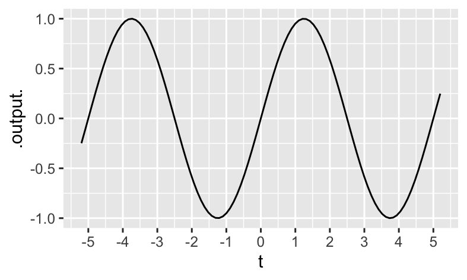

[rev-2]

[a] $t = -5$ [] $t = -2.5$ [] $t = -1.25$ [] $t = 1.25$ [] $t = 2.5$

[rev-2]

[] $t = -2.5$ [] $t = -1.25$ [a] $t = 0$ [] $t = 1.25$ [] $t = 2.5$

[rev-2]

[] $t = -2.5$ [a] $t = -1.25$ [] $t = 0$ [] $t = 1.25$ [That’s an argmin!] [] $t = 2.5$

[rev-2]

[] $t = -2.5$ [] $t = -1.25$ [That’s an argmax!] [] $t = 0$ [a] $t = 1.25$ [] $t = 2.5$

[rev-2]

[] 0 [] 1 [a] 2 [] 3 [] 4 [For a sinusoid, the amplitude is **half** the vertical peak-to-trough distance.]

[rev-2]

[] 0 [a] 1 [] 2 [] 3 [] 4

[rev-2]

[] 0 [] 1 [] 2 [a] 3 [] 4 [4 is close to the argmax, but we’re asking about the max.]

**r2-08** One of the following choices is the standard deviation of the function graphed. Which one?

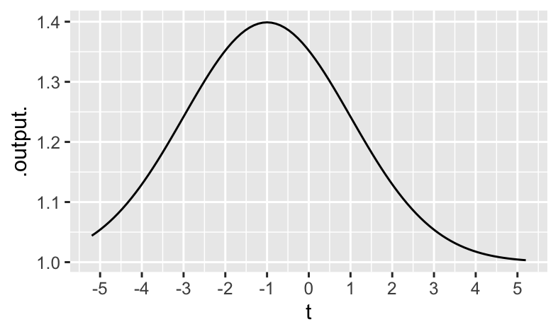

[rev-2]

[] 0 [A gaussian with 0 standard deviation would be infinitely narrow and infinitely high!] [] 1 [a] 2 [] 3 [Remember the rule of thumb: half-width at half-height] [] 4

**r2-09**

[+] $(x=0, y=6)$ [] $(x=1, y=5)$ [] $(x=-2, y=6)$ [] $(x=0, y=1)$

**r2-10**

[] $(x=0, y=6)$ [+] $(x=1, y=5)$ [] $(x=-2, y=6)$ [] $(x=0, y=1)$

**r2-11** Which of these is a positive-going zero crossing of $g(t)$?
$$g(t) \equiv \sin\left(\frac{2\pi}{5}t-3\right)$$
[rev-2]

[a] $t=15/2\pi$ [This makes the $\frac{2\pi}{5}t$ component go to 3, which cancels out the -3.] [] $t = 2 \pi/15$ [] $t = 3$ [Notice that the argument is **not** $\frac{2\pi}{5}(t-3)$.] [] None of the above

**r2-12** What is the period of $g(t)$?
$$g(t) \equiv \text{dnorm}\left(\frac{2\pi}{5}(t-3)\right)$$
[rev-2]

[] 1 [] 5 [] $2 \pi/5$ [] $5/2\pi$ [a] $g(t)$ isn’t periodic. [The only one of our basic modeling functions that is period is $\sin()$. The gaussian, that is, $\text{dnorm}()$, has just one bump and therefore isn’t periodic.]

**r2-13** What is the period of $g(t)$?
$$g(t) \equiv \frac{5}{\sin(2 \pi t)}$$
[rev-2]

[a] 1 [] 5 [Hint: 5 isn’t inside the $\sin()$ parentheses.] [] $2 \pi/5$ [Hint: 5 isn’t inside the $\sin()$ parentheses.] [] $5/2\pi$ [Hint: 5 isn’t inside the $\sin()$ parentheses.] [] $g(t)$ isn’t periodic. [Since the $\sin()$ is periodic, $1/\sin()$ is also periodic.]

**r2-14** which of the following is a positive-going zero crossing of $g(t)$?
$$\sin\left(\frac{2 \pi}{5} (t - 3) \right)$$
[rev-2]

[] $t=-5$ [5 isn’t in the $\sin()$ parentheses.] [] $t=-3$ [When the argument to $\sin()$ is zero, the function output is at zero and increasing.] [] $t=0$ [When the argument to $\sin()$ is zero, the function output is at zero and increasing.] [a] $t=3$ [$t=3$ makes the whole argument zero.] [] $t=5$ [5 isn’t in the $\sin()$ parentheses.]

**r2-15** What is the period of the function $\sin(6\pi t)$?[rev-2]

[a] 1/3 [] 1/2 [] 2 [] 3 [] 6

**r2-16**

[] $(x=0, y=6)$ [] $(x=1, y=5)$ [] $(x=-2, y=6)$ [+] $(x=0, y=1)$

**r2-17**

[] $(x=0, y=6)$ [] $(x=1, y=5)$ [+] $(x=-2, y=6)$ [] $(x=0, y=1)$

**r2-18**

[+] $(x=0, y=6)$ [] $(x=1, y=2)$ [] $(x=-2, y=3)$ [] $(x=0, y=1)$

**r2-19**

[a] NE [] SE [] SW [It’s steep in this direction, but **downhill**!] [] NW

**r2-20**

[] NE [It’s steep in this direction, but **downhill**!] [] SE [a] SW [] NW

**r2-21**

[+] NW or SE [] SE but not NW [Flat works both ways. If NW keeps you on a contour, so will SE (at least instantaneously).] [] NW but not SE [Flat works both ways. If NW keeps you on a contour, so will SE (at least instantaneously).] [] NE or SW [That’s going downhill or uphill, respectively.]

[rev-2]

[] 1 [] 2 [] 3 [] 4 [a] 5

**r2-23** Which function(s) have $k < 0$?

[figure not shown]

[rev-2]

[] blue [a] black [] both [] neither

**r2-24** Which function(s) have $k < 0$?

[figure not shown]

[rev-2]

[] blue [] black [] both [a] neither [As the input gets bigger, both functions produce outputs that get further from their respective baselines. That’ exponential growth.]

**r2-25** Which function(s) have $k < 0$?

[figure not shown]

[rev-2]

[] blue [Exponential decay means that the function output gets closer and closer to baseline as the input gets bigger.] [] black [] both [a] neither [As the input gets bigger, both functions produce outputs that get further from their respective baselines. That’ exponential growth.]

**r2-26** One of the functions has a half-life, the other a doubling time. Which is bigger, the half-life or the doubling time?

[figure not shown]

[rev-2]

[] doubling time [a] half-life [] about the same [] they aren’t exponential, so the concept of half-life/doubling-time doesn’t apply.

**r2-27** What is the instantaneous rate of change of this function when the input is $t=-3$?

[figure not shown]

(Choose the closest answer.) [rev-2]

[a] 0.5 [] 1 [] 1.5 [] 2

**r2-28** What is the average rate of change of this function on the interval $-5 < t < 5?

[figure not shown]

(Choose the closest answer.) [rev-2]

[a] 0.5 [Rise is 5, run is 10.] [] 1 [] 1.5 [] 2

**r2-29** Consider the average rate of change of this function on the interval $-2 < t 2$.

[figure not shown]

Which of these statements best describes the average rate of change. [rev-2]

[] very close to 1/2 [a] slightly less than 1 [] slightly greater than 1 [] very close to 2